# Ridge regularization for spatial auto-regressive models with multicollinearity issues

Application of RRSAR and RRSEM to COVID-19 dataset

Chavez-Chong, C., Hardouin, C., Fermin, A.K.

## Introduction

In this document we present de code to reproduce the results of applying the RRSAR and RRSEM methodologies to real life data. The data is related to the Covid-19 epidemic in metropolitan France, in 2020. The aim of the study is to determine whose socio-economic variables have a significant impact on the hospitalization rate for COVID-19.

## Load data

We start by loading spatial data `covid_data.shp` which contains 12 variables and a geometry column type Multi Polygon. The observations are collected from the 96 **départements**, which are administrative units.

The variables are:

- `Department`: name of the French department.
- `Region`: name of the French region.
- `LnHosp`: logarithm of hospitalization rate.
- `LnPop` : logarithm of population density.
- `SLivR` : standard of living gap.
- `C3` : percentage of inhabitants in the three largest cities of the department.
- `Work` : rate of workers.
- `Inac` : inactive rate.
- `A65pls` : share of people aged 65 and over.
- `Emer` : number of emergency services per 1000 habitants.
- `FDoc` : number of doctors per 1000 habitants.
- `Urban`: indicator of an urban department.

Also, we load the required functions.

```r
setwd("C:/Users/crist/OneDrive/Documents/Covid19France") #change to appropiate
source("scripts/functions_covid.R")
france_departement_covid_sf <- st_read("data/covid_data.shp")
## Reading layer `covid_data' from data source `C:\Users\crist\OneDrive\Documents\Covid19France\data\covid_data.shp' using driver `ESRI Shapefile'
## Simple feature collection with 96 features and 17 fields
## geometry type:  MULTIPOLYGON
## dimension:      XY
## bbox:           xmin: -5.138001 ymin: 41.36216 xmax: 9.559226 ymax: 51.08854
## epsg (SRID):    4326
## proj4string:    +proj=longlat +datum=WGS84 +no_defs
```

## Exploratory data analysis

We calculate deciles of the variable `LnHosp` using the function `quantile()` and then we create a new variable named `LnHosp_decil` that assigns decile labels to each value in the `LnHosp` column based on the calculated deciles. Finally, we plot a map to visualize the distribution of hospitalization rates in French departments, with each department shaded according to its decile.

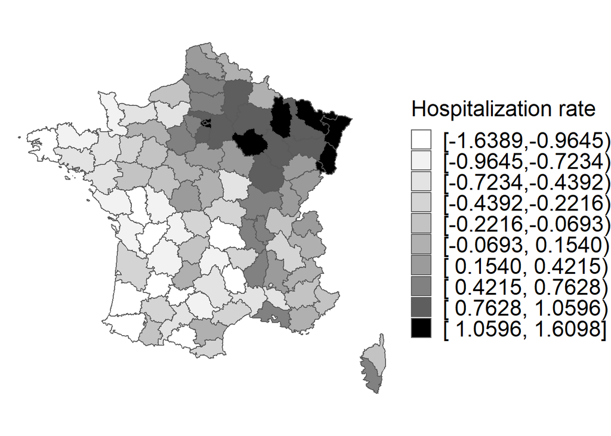

```r
quantiles <- quantile(france_departement_covid_sf$LnHosp, prob = seq(0, 1, length = 11), type = 5)
plotdata <-france_departement_covid_sf%>%
  mutate(LnHosp_decil = cut2(france_departement_covid_sf$LnHosp, cuts = as.numeric(quantiles)))


ggplot(plotdata) +
geom_sf(aes(fill = LnHosp_decil))+
scale_fill_grey(start=1, end=0, name = "Hospitalization rate")+
theme_void()+
theme(legend.title =element_text(size=18), legend.text = element_text(size=18))
```

We prepare the spatial data by converting the spatial data frame `france_departement_covid_sf` into a `Spatial` object, extract coordinates and store them in the `covid.coords` variable, define neighbors based on the Queen contiguity criterion, and calculate spatial lags up to a lag order of 4 using the neighbor list `Neigh`.

```r
france_departement_covid_sd<- as(france_departement_covid_sf, "Spatial")
covid.coords <-coordinates(france_departement_covid_sd)
Neigh <- poly2nb(france_departement_covid_sd, row.names = NULL, queen=TRUE)
covid.lags <- nblag(Neigh, 4)
dlist <- nbdists(covid.lags[[1]], coordinates(covid.coords), longlat=TRUE)
  inv_dlist <- lapply(dlist, function(x) 1/(x))
  listw  <- nb2listw(covid.lags[[1]],style="B",glist =inv_dlist, zero.policy = TRUE)
  mat_w <- listw2mat(listw)
  mat_w <- mat_w/eigen(mat_w)$values[1]
  listw_1 <-mat2listw(mat_w)
```

We construct a function `compute_morans_i` that computes Moran’s I for a given order and returns a summary of the results as a named vector. We use `lapply` to apply the `compute_morans_i` function to each order and store the results in a list. We combine the results from the list into a data frame using `do.call(rbind, results)`. Finally, we use `knitr::kable` to display the results in a table.

```r
compute_morans_i <- function(order) {
  dlist <- nbdists(covid.lags[[order]], coordinates(covid.coords), longlat=TRUE)
  inv_dlist <- lapply(dlist, function(x) 1/(x))
  listw  <- nb2listw(covid.lags[[order]],style="B",glist =inv_dlist, zero.policy = TRUE)
  moran_result <- moran.test(france_departement_covid_sf$LnHosp, listw = listw, zero.policy = TRUE, alternative = "two.sided", na.action = na.omit)
  return(c(Lag_Order = order,
           MoransI = moran_result$estimate,
           Statistic = moran_result$statistic,
           p_value = moran_result$p.value))
}

lag_orders <- 1:4
results <- lapply(lag_orders, compute_morans_i)


results_df <- as.data.frame(do.call(rbind, results))%>%
  mutate(p_value=format(as.numeric(p_value), digits = 3, trim = F))
colnames(results_df)<- c("Lag", "MoransI", "Mean", "Variance", "Statistic", "p-value")
knitr::kable(results_df, digits=3)%>%
  kable_styling(c("striped", "bordered"))
```

| Lag | MoransI | Mean | Variance | Statistic | p-value |
| --- | --- | --- | --- | --- | --- |
| 1 | 0.989 | -0.011 | 0.007 | 12.130 | 7.31e-34 |
| 2 | 0.576 | -0.011 | 0.002 | 11.982 | 4.40e-33 |
| 3 | 0.353 | -0.011 | 0.002 | 9.287 | 1.58e-20 |
| 4 | 0.189 | -0.011 | 0.001 | 5.513 | 3.52e-08 |

## Principal Components Analysis

We prepare the data to perfom Principal Components Analysis (PCA), first, we create a new dataset called `data` by selecting specific columns from the `france_departement_covid_sf`, then we remove the spatial geometry information from the `data` object, finally, we set the row names of `data` to be the values from the `Department` column.

```r
data <- france_departement_covid_sf%>%dplyr::select(Urban,LnPop,SLivR,C3, Work,
                                             Inac, A65pls, Emer, FDoc,LnHosp)
st_geometry(data) <- NULL


rownames(data) <- france_departement_covid_sf$Department
```

We perform PCA and store the results in `covid_france.pca`. With the `quali.sup = c(1)` portion, we specify that we consider `Urban` as a supplementary qualitative variable. Similarly, with `quanti.sup = c(10)`, we specify that we consider `LnHosp` as a supplementary quantitative variable

```r
covid_france.pca <- PCA(data, quanti.sup = c(10),quali.sup = c(1), graph = FALSE)
```

We create a scatterplot of PCA variable contributions.

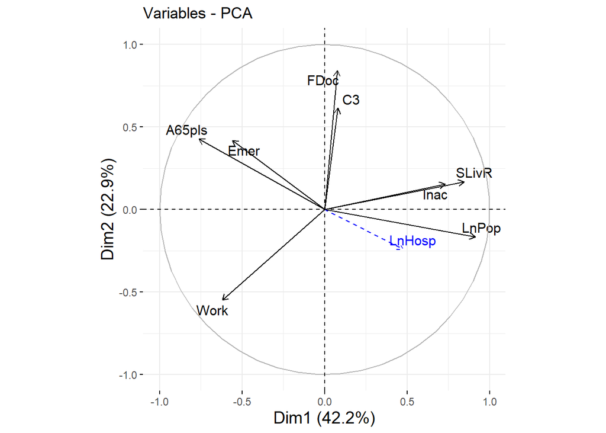

```r
fviz_pca_var(covid_france.pca,  axes = c(1,2),  col.var = "black", repel = TRUE )+
  theme(axis.title =element_text(size=14))
```

We generate PCA plot of individuals in the space of the first two principal components, with color differentiation based on the `Urban` variable.

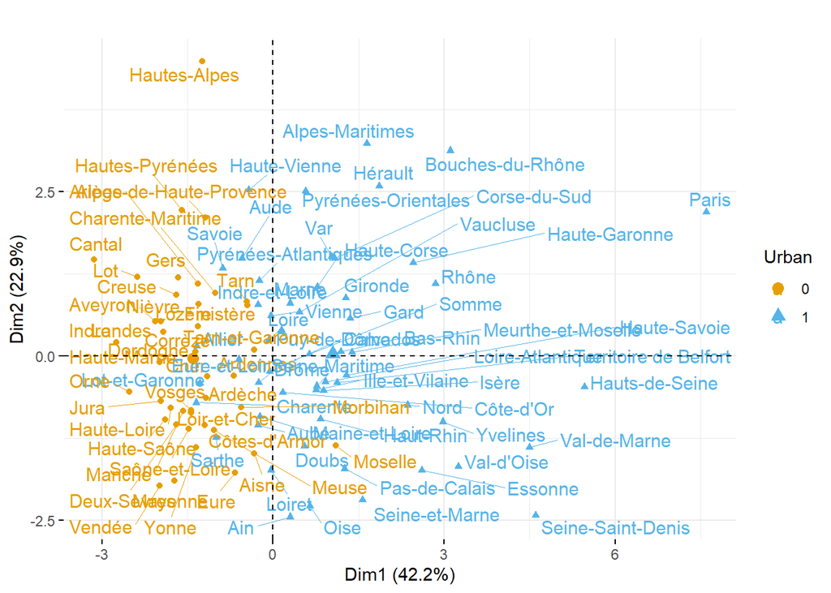

```r
groups <- as.factor(data$Urban)
fviz_pca_ind(covid_france.pca,
             col.ind = groups,
             palette = c( "#E69F00", "#56B4E9"),
             legend.title = "Urban",
             repel = TRUE,
             title= ""
)
```

We generate PCA plot of individuals in the space of the first two principal components, with color differentiation based on the `Region` variable.

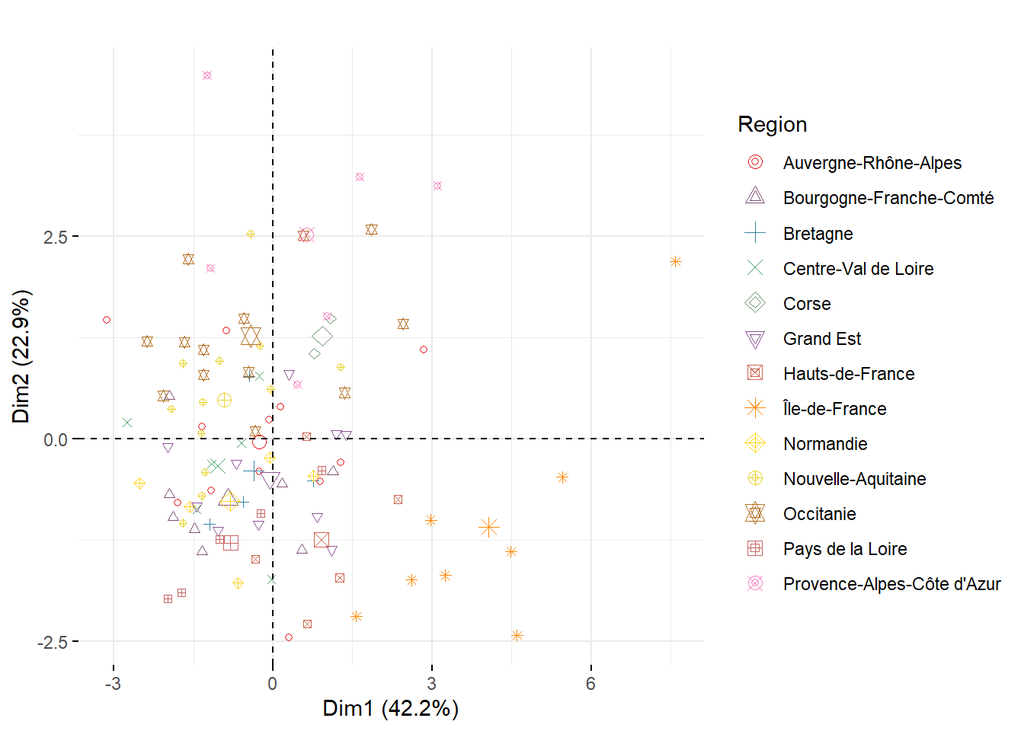

```r
nb.cols <- 13
mycolors <- colorRampPalette(brewer.pal(8, "Set1"))(nb.cols)

groups <- as.factor(france_departement_covid_sf$Region)
fviz_pca_ind(covid_france.pca,
             col.ind = groups, # color by groups
             repel = TRUE,
             palette = mycolors,
             geom.ind = "point",
             legend.title = "Region",
             title=""
)
```

## Estimation

In this study, our main objective is to discern the significant contributors among the explanatory variables to the propagation of Covid-19, particularly in terms of the hospitalization rate when the admissions are directly linked to the disease. To achieve this, we employ SAR and SEM techniques, both with and without Ridge regularization. This approach allows us to evaluate the outcomes and assess the impact of RRSAR and RRSEM.

Lets set the structure of the model we are considering and the size of the buffer for SLOO.

```r
model <- LnHosp ~LnPop+C3+SLivR+
  Work+Inac+A65pls+
  Emer+FDoc - 1

buffer=1
```

We store the sample standard deviations- in `std_deviations` of the covariates before centering and scaling the covariates and centering the dependent variable `LnHosp`.

```r
std_deviations <- st_drop_geometry( france_departement_covid_sf) %>%
  dplyr::select(LnPop, C3, SLivR, Work, Inac, A65pls, Emer, FDoc) %>%
  summarise_all(sd)%>%as.numeric()
```

```r
data <-  france_departement_covid_sf %>%
  mutate(
    # Standardize the variables
    LnPop = scale(LnPop),
    C3 = scale(C3),
    SLivR = scale(SLivR),
    Work = scale(Work),
    Inac = scale(Inac),
    A65pls = scale(A65pls),
    Emer = scale(Emer),
    FDoc = scale(FDoc),

    # Center the variable
    LnHosp = scale(LnHosp, scale = FALSE)
  )
```

We estimate SAR and SEM models without regularization and store the results in `sar` and `sem`, respectively.

```r
 sar <- spatialreg::lagsarlm(model,data=data,listw_1)
 sar <-summary(sar)
 sem <- spatialreg::errorsarlm(model,data=data,listw_1)
 sem <- summary(sem)
```

We utilize two essential functions, `rrsar` and `rrsem`, available in the loaded script to estimate coefficients for the RRSAR and RRSEM models, respectively. For these estimations, we provide the following specifications:

- `data`: This refers to a dataframe containing the relevant variables used in our model.
- `model`: The model object holds the specific model structure being employed.
- `buffer`: It represents the size of the buffer considered in the Spatial Leave One Out analysis.
- `plot`: By setting this variable to TRUE, we indicate that we wish to generate plots displaying the evolution of coefficient values and log-likelihood concerning variations in $\log(\gamma)$.

Due to the usa of SLOO the following code chunk can take more less a minute to run.

```r
coef_RRSAR <- rrsar(data, model, buffer, plot=TRUE)
coef_RRSEM <- rrsem(data, model, buffer, plot=TRUE)
```

We use, `perm_f_test_parallel`, available in the loaded script to perform a permutation test to assess the influence of the explanatory variables on the dependent variable. We consider:

- `data`: This refers to a dataframe containing the relevant variables used in our model.
- `model`: The model object holds the specific model structure being employed.
- `B`: The number of permutations.
- `buffer`: It represents the size of the buffer considered in the Spatial Leave One Out analysis.

```r
p_F_test<-perm_f_test_parallel(data, model, B=100, buffer = 1)
```

We also perform a t-test for the importance of the variables.

```r
mt <- terms(model, data = data)
mf <- lm(model, data,
         method="model.frame")

y <- model.extract(mf, "response")

x <- model.matrix(mt, mf)


n <- nrow(x) # number of observations
p <- ncol(x)  # number of covariates
wy <- mat_w%*%y
WX <- mat_w%*%x
```

```r
# RRSAR
# Compute sigma^2 estimate
rho_rrsar <- coef_RRSAR$rho
beta_ridge_rrsar <- coef_RRSAR$Coefficients
gamma_rrsar <- coef_RRSAR$gamma

y_filtered <-  y - rho_rrsar*wy

e_rho = y_filtered - x%*%beta_ridge_rrsar

sigma2_rrsar <- crossprod(e_rho)/(n-p)


# compute variance of beta_ridge
diag_var_matrix <- diag(solve(crossprod(x) + diag(gamma_rrsar, (p)))%*%crossprod(x)%*%solve(crossprod(x) + diag(gamma_rrsar, (p))))

var_beta <- as.vector(sigma2_rrsar)*diag_var_matrix

std_dev_beta_rige <- sqrt(var_beta)

# Compute t statistic
t_statistic_sar <- beta_ridge_rrsar/std_dev_beta_rige

# Compute p-value
df= n - p

# Calculate p-value for a two-tailed t-test
p_value_sar <- 2 * (1 - pt(abs(t_statistic_sar), df))
```

```r
# RRSEM
# Compute sigma^2 estimate
lambda_rrsem <- coef_RRSEM$lambda
beta_ridge_rrsem <- coef_RRSEM$Coefficients
gamma_rrsem <- coef_RRSEM$gamma

x_filtered <- x - lambda_rrsem*WX
y_filtered <- y - lambda_rrsem*wy

e_lambda = y_filtered - (x_filtered)%*%beta_ridge_rrsem

sigma2_rrsem <- crossprod(e_lambda)/(n-p)


# compute variance of beta_ridge
diag_var_matrix <- diag(solve(crossprod(x_filtered) + diag(gamma_rrsem, (p)))%*%crossprod(x_filtered)%*%solve(crossprod(x_filtered) + diag(gamma_rrsem, (p))))

var_beta <- as.vector(sigma2_rrsem)*diag_var_matrix

std_dev_beta_rige <- sqrt(var_beta)

# Compute t statistic
t_statistic_sem <- beta_ridge_rrsem/std_dev_beta_rige

# Compute p-value
df= n - p

p_value_sem <- 2 * (1 - pt(abs(t_statistic_sem), df))
```

And a permutation t-test for the importance of the variables.

```r
covariatevarnames <- colnames(x)

p_t_test <- data.frame(SAR = c(NA, NA, NA, NA, NA, NA, NA, NA),
                       SEM = c(NA, NA, NA, NA, NA, NA, NA, NA))

rownames(p_t_test) <- covariatevarnames

B=100

for (j in covariatevarnames){



# Obtain list with B permutation of variable x_j
covar_j <- st_drop_geometry(data[,j])
perm_j <- replicate(B, sample(as.matrix(covar_j),size=n, replace = TRUE), simplify = FALSE)



# Create function to compute
compute_t_test_perm <- function(perm_j){
  data_perm <- data
  data_perm[,j]<-perm_j

  # Extract response variable and covariate matrix
  mt <- terms(model, data = data_perm)
  mf <- lm(model, data_perm, method = "model.frame")
  y <- model.extract(mf, "response")
  x <- model.matrix(mt, mf)


  wy <- mat_w %*% y
  WX <- mat_w %*% x



  # RRSAR (Ridge Regression for SAR) ----

  # Get ridge coefficient estimates
  coef_RRSAR <- rrsar(data_perm, model, buffer, plot = TRUE)
  rho_rrsar <- coef_RRSAR$rho
  gamma_rrsar <- coef_RRSAR$gamma
  beta_ridge_rrsar <- coef_RRSAR$Coefficients

  # Compute sigma^2 estimate
  y_filtered <-  y - rho_rrsar * wy
  e_rho <- y_filtered - x %*% beta_ridge_rrsar
  sigma2_rrsar <- crossprod(e_rho) / (n - p)

  # Compute the standard deviation of beta_ridge_j
  diag_var_matrix <- diag(solve(crossprod(x) + diag(gamma_rrsar, (p)))%*%crossprod(x)%*%solve(crossprod(x) + diag(gamma_rrsar, (p))))

  var_beta <- as.vector(sigma2_rrsar)*diag_var_matrix

  std_dev_beta_rige <- sqrt(var_beta[j])

  # Compute t-statistic and p-value for significance
  statistic_perm_sar <- beta_ridge_rrsar[j]/std_dev_beta_rige


  # RRSEM (Ridge Regression for SEM) ----

  # Get ridge coefficient estimates
  coef_RRSEM <- rrsem(data_perm, model, buffer, plot = TRUE)
  lambda_rrsem <- coef_RRSEM$lambda
  gamma_rrsem <- coef_RRSEM$gamma
  beta_ridge_rrsem <- coef_RRSEM$Coefficients

  # Compute sigma^2 estimate
  x_filtered <- x - lambda_rrsem*WX
  y_filtered <- y - lambda_rrsem*wy

  e_lambda = y_filtered - (x_filtered)%*%beta_ridge_rrsem

  sigma2_rrsem <- crossprod(e_lambda)/(n-p)

  # Compute the standard deviation of beta_ridge_j
  diag_var_matrix <- diag(solve(crossprod(x_filtered) + diag(gamma_rrsem, (p)))%*%crossprod(x_filtered)%*%solve(crossprod(x_filtered) + diag(gamma_rrsem, (p))))

  var_beta <- as.vector(sigma2_rrsem)*diag_var_matrix

  std_dev_beta_rige <- sqrt(var_beta[j])

  # Compute t-statistic
  statistic_perm_sem <- beta_ridge_rrsem[j]/std_dev_beta_rige

  results <- matrix(NA,2,1)
  rownames(results)<-c("SAR", "SEM")
  results["SAR",]<-statistic_perm_sar
  results["SEM",]<-statistic_perm_sem
  return(results)
}


statistic_perm <- t(sapply(perm_j, compute_t_test_perm, simplify = TRUE))

colnames(statistic_perm) <- c("SAR", "SEM")
# Count how many values in each column are greater than the thresholds
p_sar_j <- (1/B)*(sum(statistic_perm[,"SAR"] >= t_statistic_sar[j]))
p_sem_j <-(1/B)*( sum(statistic_perm[,"SEM"] >= t_statistic_sem[j]))



p_t_test[j,"SAR"] <- format(p_sar_j, digits = 4)
p_t_test[j,"SEM"] <- format(p_sem_j, digits = 4)


}
```

Finally, we present the results in two tables, one for SAR and one for SEM. Due to the random choice of permutations, the following results somewhat differ from those presented in our paper.

```r
p_val_rho_rrsar <- format(as.numeric(coef_RRSAR[["pvalue"]]), digits = 0, trim = F, nsmall = 4)
p_val_coef_rrsar <- format(as.numeric(p_F_test$SAR), digits = 0, trim = F, nsmall = 4)

p_val_rho_rrsem <- format(as.numeric(coef_RRSEM[["pvalue"]]), digits = 0, trim = F, nsmall = 4)
p_val_coef_rrsem <- format(as.numeric(p_F_test$SEM), digits = 0, trim = F, nsmall = 4)


p_val_pt_coef_rrsar <- format(as.numeric(p_t_test$SAR), digits = 0, trim = F, nsmall = 4)
p_val_pt_coef_rrsem <- format(as.numeric(p_t_test$SEM), digits = 0, trim = F, nsmall = 4)



dt_sar <- data.frame(coefsar=c(sar[["Coef"]][,1]/std_deviations,NA,sar[["rho"]][["rho"]]),
                 pvaluesar = c(sar[["Coef"]][,4],NA,as.numeric(sar[["LR1"]][["p.value"]])),
                 coefsar_ridge=c(coef_RRSAR[["Coefficients"]]/std_deviations,coef_RRSAR[["gamma"]],
                           coef_RRSAR[["rho"]]),
                 pvaluesar_ridge=c( p_val_coef_rrsar, NA,p_val_rho_rrsar),
                  pvaluesar_halawa=c( p_value_sar, NA,NA),
                  pvaluesar_perm_ttest=c( p_val_pt_coef_rrsar, NA,NA)

               )

  rownames(dt_sar) <-c(rownames(p_F_test),"$\\gamma$", "$\\rho$")


  dt_sem <- data.frame(coefsem=c(sem[["Coef"]][,1]/std_deviations,NA,sem[["lambda"]][["lambda"]]),
                 pvaluesem = c(sem[["Coef"]][,4],NA,as.numeric(sem[["LR1"]][["p.value"]])),
                 coefsem_ridge=c(coef_RRSEM[["Coefficients"]]/std_deviations,coef_RRSEM[["gamma"]],
                           coef_RRSEM[["lambda"]]),
                 pvaluesem_ridge=c( p_val_coef_rrsem, NA,p_val_rho_rrsem),
               pvaluesem_halawa=c( p_value_sem, NA,NA),
                  pvaluesem_perm_ttest=c(p_val_pt_coef_rrsem, NA,NA)
               )

  rownames(dt_sem) <-c(rownames(p_F_test),"$\\gamma$", "$\\lambda$")


opts <- options(knitr.kable.NA = "")
knitr::kable(dt_sar,  col.names = c("Coef",
                                "p-value",
                                "Coef",
                                "Perm. F-test p-value",
                                "t-test p-value",
                                "Perm. t-test p-value" ), digits = 4)%>%
  kable_styling(c("striped", "bordered")) %>%
  add_header_above(c("",
                     "SAR" = 2,"RRSAR" = 4))
```

|  | SAR Coef | SAR p-value | RRSAR Coef | RRSAR Perm. F-test p-value | RRSAR t-test p-value | RRSAR Perm. t-test p-value |
| --- | --- | --- | --- | --- | --- | --- |
| LnPop | -0.1256 | 0.2297 | -0.0006 | 0.9400 | 0.9854 | 0.4900 |
| C3 | 0.5337 | 0.4365 | 0.3333 | 0.6300 | 0.5117 | 0.2600 |
| SLivR | 0.6277 | 0.0029 | 0.2593 | 0.0200 | 0.0050 | 0.0200 |
| Work | 12.8074 | 0.0019 | 6.7131 | 0.0100 | 0.0023 | 0.0100 |
| Inac | 6.7543 | 0.0742 | 5.1264 | 0.0500 | 0.0324 | 0.0100 |
| A65pls | -0.0357 | 0.1713 | -0.0257 | 0.1200 | 0.0305 | 0.9900 |
| Emer | -6.6582 | 0.6206 | -4.8059 | 0.6800 | 0.5923 | 0.7100 |
| FDoc | -0.1584 | 0.7012 | -0.2118 | 0.9700 | 0.4179 | 0.8500 |
| $\gamma$ |  |  | 34.2557 |  |  |  |
| $\rho$ | 0.8489 | 0.0001 | 0.7282 | 0.0003 |  |  |

```r
opts <- options(knitr.kable.NA = "")
knitr::kable(dt_sem,  col.names = c("Coef",
                                "p-value",
                                "Coef",
                                "Perm. F-test p-value",
                                "t-test p-value",
                                "Perm. t-test p-value" ), digits = 4)%>%
  kable_styling(c("striped", "bordered")) %>%
  add_header_above(c("",
                     "SEM" = 2,"RRSEM" = 4))
```

|  | SEM Coef | SEM p-value | RRSEM Coef | RRSEM Perm. F-test p-value | RRSEM t-test p-value | RRSEM Perm. t-test p-value |
| --- | --- | --- | --- | --- | --- | --- |
| LnPop | -0.0363 | 0.7775 | 0.0211 | 0.5900 | 0.5066 | 0.2200 |
| C3 | 0.4144 | 0.5608 | 0.2672 | 0.7800 | 0.5942 | 0.2700 |
| SLivR | 0.6293 | 0.0036 | 0.2455 | 0.0000 | 0.0100 | 0.0200 |
| Work | 12.0400 | 0.0101 | 5.1042 | 0.0300 | 0.0197 | 0.0100 |
| Inac | 6.0018 | 0.1553 | 4.1157 | 0.1600 | 0.0764 | 0.0100 |
| A65pls | -0.0284 | 0.3336 | -0.0213 | 0.1500 | 0.0658 | 0.9700 |
| Emer | -3.4274 | 0.8062 | -4.9290 | 0.6800 | 0.5714 | 0.7600 |
| FDoc | -0.2583 | 0.5795 | -0.2010 | 0.6200 | 0.4351 | 0.8200 |
| $\gamma$ |  |  | 38.0189 |  |  |  |
| $\lambda$ | 0.8549 | 0.0047 | 0.8996 | 0.0000 |  |  |